# Quiz 2- Time Series and Forecasting

Ivy Kemunto

2024-05-22

$$\begin{array}{|c|c|c|c|c|c|c|c|c|c|c|}
\hline
\text{Year} & 2011 & 2012 & 2013 & 2014 & 2015 &
2016 & 2017 & 2018 & 2019 & 2020 \\
\hline
\text{GDP} & 35 & 37 & 51 & 54 & 62 &
64 & 74 & 71 & 83 & 80 \\
\hline
\end{array}$$

## i. Fit a trend line for GDP data and find trend values with the help of trendline.

To answer this question , we need to use the following formulas:

1. **Linear Trend Model** The linear trend model assumes a linear relationship between the GDP and the years. The equation for the linear trend is:

   $$Y_t = \beta_0 + \beta_1 t$$

   Where:
   - $Y_t$ is the GDP at time $t$
   - $\beta_0$ is the intercept
   - $\beta_1$ is the slope of the trend line

   We can estimate the coefficients $\beta_0$ and $\beta_1$ using the least squares method.
2. **Quadratic Trend Model** The quadratic trend model assumes a curvilinear relationship between the GDP and the years. The equation for the quadratic trend is:

   $$Y_t = \beta_0 + \beta_1 t + \beta_2 t^2$$

   Where:
   - $Y_t$ is the GDP at time $t$
   - $\beta_0$, $\beta_1$, and $\beta_2$ are the coefficients
3. **Exponential Trend Model** The exponential trend model assumes an exponential relationship between the GDP and the years. The equation for the exponential trend is:

   $$Y_t = \beta_0 e^{\beta_1 t}$$

   Alternatively, taking the natural logarithm:

   $$\log(Y_t) = \log(\beta_0) + \beta_1 t$$

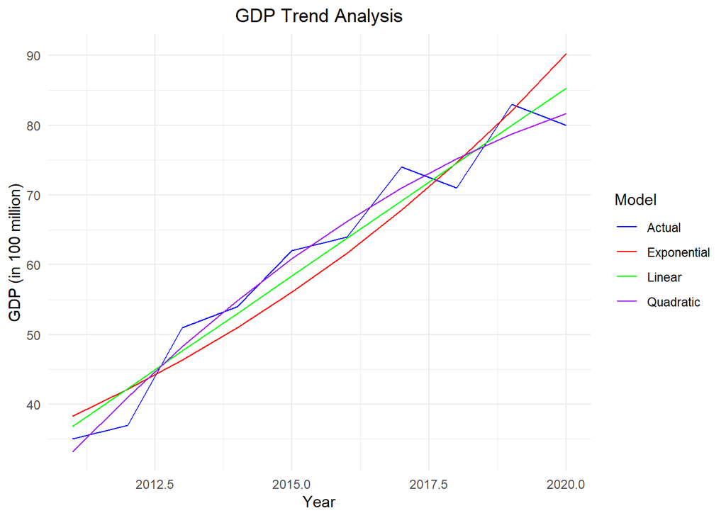

```r
#librarY
library(ggplot2)
#Data
years<-2011:2020
gdp<-c(35, 37, 51, 54, 62, 64, 74, 71, 83, 80)
#data frame
data<-data.frame(years,gdp)
#Linear regression model
linear_model<-lm(gdp~years,data=data)
linear_trend<-predict(linear_model,data)
# Quadratic regression model
quadratic_model<-lm(gdp~poly(years,2,raw=TRUE),data=data)
quadratic_trend<-predict(quadratic_model, data)
#Exponential regression model
exp_model<-lm(log(gdp)~years,data=data)
exp_trend<-exp(predict(exp_model,data))
#data frame for trends
trend_data<-data.frame(years=rep(years,4),gdp=c(gdp,linear_trend,quadratic_trend,exp_trend),model=rep(c("Actual","Linear","Quadratic","Exponential"),each=length(years)))
#Plot
ggplot(trend_data,aes(x=years,y=gdp,color=model))+geom_line(size=0.5)+scale_color_manual(values=c("blue","red","green","purple"))+labs(title='GDP Trend Analysis',x='Year',y='GDP (in 100 million)',color="Model")+theme_minimal()+theme(plot.title=element_text(hjust=0.5))
```

```r
#Output model summaries to determine the best fit
summary(linear_model)
```

```
##
## Call:
## lm(formula = gdp ~ years, data = data)
##
## Residuals:
##     Min      1Q  Median      3Q     Max
## -5.3455 -3.1409  0.5939  3.2879  4.8182
##
## Coefficients:
##               Estimate Std. Error t value Pr(>|t|)
## (Intercept) -1.080e+04  8.945e+02  -12.07 2.05e-06 ***
## years        5.388e+00  4.438e-01   12.14 1.96e-06 ***
## ---
## Signif. codes:  0 '***' 0.001 '**' 0.01 '*' 0.05 '.' 0.1 ' ' 1
##
## Residual standard error: 4.031 on 8 degrees of freedom
## Multiple R-squared:  0.9485, Adjusted R-squared:  0.9421
## F-statistic: 147.4 on 1 and 8 DF,  p-value: 1.962e-06
```

```r
summary(quadratic_model)
```

```
##
## Call:
## lm(formula = gdp ~ poly(years, 2, raw = TRUE), data = data)
##
## Residuals:
##     Min      1Q  Median      3Q     Max
## -4.1758 -2.0909  0.1667  2.5182  4.2545
##
## Coefficients:
##                               Estimate Std. Error t value Pr(>|t|)
## (Intercept)                 -1.242e+06  6.032e+05  -2.059   0.0785 .
## poly(years, 2, raw = TRUE)1  1.227e+03  5.986e+02   2.050   0.0796 .
## poly(years, 2, raw = TRUE)2 -3.030e-01  1.485e-01  -2.041   0.0806 .
## ---
## Signif. codes:  0 '***' 0.001 '**' 0.01 '*' 0.05 '.' 0.1 ' ' 1
##
## Residual standard error: 3.412 on 7 degrees of freedom
## Multiple R-squared:  0.9677, Adjusted R-squared:  0.9585
## F-statistic: 104.9 on 2 and 7 DF,  p-value: 6.043e-06
```

```r
summary(exp_model)
```

```
##
## Call:
## lm(formula = log(gdp) ~ years, data = data)
##
## Residuals:
##      Min       1Q   Median       3Q      Max
## -0.12955 -0.07978  0.02416  0.07974  0.10072
##
## Coefficients:
##               Estimate Std. Error t value Pr(>|t|)
## (Intercept) -188.03153   21.30489  -8.826 2.14e-05 ***
## years          0.09531    0.01057   9.017 1.83e-05 ***
## ---
## Signif. codes:  0 '***' 0.001 '**' 0.01 '*' 0.05 '.' 0.1 ' ' 1
##
## Residual standard error: 0.09601 on 8 degrees of freedom
## Multiple R-squared:  0.9104, Adjusted R-squared:  0.8992
## F-statistic: 81.31 on 1 and 8 DF,  p-value: 1.828e-05
```

# Linear Trend Model

The linear trend model is given by:

$$Y_t = \beta_0 + \beta_1 t$$

**Coefficients:**

- Intercept ($\beta_0$): -10800
- Slope ($\beta_1$): 5.388

**Interpretation:**

- **Intercept (**$\beta_0$): -10800 (The GDP value when the year is 0, which is not meaningful in this context since we don’t have data for year 0).
- **Slope (**$\beta_1$): 5.388 (For each year increase, the GDP increases by 5.388 units).

**Model Summary:**

- **Residual Standard Error**: 4.031
- **Multiple R-squared**: 0.9485 (94.85% of the variability in GDP can be explained by the linear model).
- **Adjusted R-squared**: 0.9421 (Adjusted for the number of predictors in the model).
- **F-statistic**: 147.4 with a p-value of 1.962e-06 (Highly significant, indicating that the model is a good fit).

# Quadratic Trend Model

The quadratic trend model is given by:

$$Y_t = \beta_0 + \beta_1 t + \beta_2
t^2$$

**Coefficients:**

- Intercept ($\beta_0$): -1.242e+06
- $\beta_1$: 1.227e+03
- $\beta_2$: -3.030e-01

**Interpretation:**

- **Intercept (**$\beta_0$): -1242000 (The GDP value when the year is 0, which is not meaningful in this context).
- $\beta_1$: 1.227e+03 (Linear term coefficient).
- $\beta_2$: -3.030e-01 (Quadratic term coefficient).

**Model Summary:**

- **Residual Standard Error**: 3.412
- **Multiple R-squared**: 0.9677 (96.77% of the variability in GDP can be explained by the quadratic model).
- **Adjusted R-squared**: 0.9585
- **F-statistic**: 104.9 with a p-value of 6.043e-06 (Highly significant, indicating that the model is a good fit).

# Exponential Trend Model

The exponential trend model is given by:

$$\log(Y_t) = \log(\beta_0) + \beta_1
t$$

**Coefficients:**

- Intercept ($\log(\beta_0)$): -188.03153
- $\beta_1$: 0.09531

**Interpretation:**

- **Intercept (**$\log(\beta_0)$): -188.03153 (log-transformed GDP value when the year is 0, not directly interpretable in the original scale).
- $\beta_1$: 0.09531 (For each year increase, the log of GDP increases by 0.09531 units).

**Model Summary:**

- **Residual Standard Error**: 0.09601
- **Multiple R-squared**: 0.9104 (91.04% of the variability in the log of GDP can be explained by the exponential model).
- **Adjusted R-squared**: 0.8992
- **F-statistic**: 81.31 with a p-value of 1.828e-05 (Highly significant, indicating that the model is a good fit).

# Conclusion

Based on the R-squared values and the F-statistics, we can conclude that all three models are statistically significant and provide a good fit for the GDP data. The quadratic model has the highest R-squared value (96.77%), indicating that it explains the most variability in GDP among the three models. # Trend Models and Visual Interpretation

## Actual Data (Blue Line)

The blue line represents the actual GDP data from 2011 to 2020.

## Linear Trend (Green Line)

The green line represents the linear trend. It shows a steady, linear increase in GDP over the years.

- The linear model fits well but may not capture the curvature in the data as effectively as the quadratic model.

## Quadratic Trend (Purple Line)

The purple line represents the quadratic trend. It captures the curvature in the data better than the linear model.

- The quadratic model has the highest R-squared value, indicating the best fit among the three models.

## Exponential Trend (Red Line)

The red line represents the exponential trend. It shows a continuously accelerating growth in GDP.

- The exponential model fits the data well but less effectively than the quadratic model.

## Conclusion

Based on the R-squared values and the visual fit, the quadratic model appears to be the best fit for the GDP data. It captures the curvature in the data better than the linear model and explains a higher percentage of the variability in GDP compared to the exponential model.

## ii. Find forecast errors.

## Forecast error

In order to calculate the forecast errors , we proceed as follows:

The forecast error formula is given by:

$$\text{Forecast Error} = \text{Actual
Value} - \text{Predicted Value}$$

```r
#Calculating forecast errors
forecast_errors<-data.frame(years=years,actual=gdp,linear_error=gdp-linear_trend,quadratic_error=gdp-quadratic_trend,exponential_error=gdp-exp_trend)
#forecast errors dataframe
print(forecast_errors)
```

```
##    years actual linear_error quadratic_error exponential_error
## 1   2011     35   -1.8545455       1.7818182        -3.2887842
## 2   2012     37   -5.2424242      -4.0303030        -5.1178284
## 3   2013     51    3.3696970       2.7636364         4.6702064
## 4   2014     54    0.9818182      -0.8363636         3.0370265
## 5   2015     62    3.5939394       1.1696970         5.9405085
## 6   2016     64    0.2060606      -2.2181818         2.3343166
## 7   2017     74    4.8181818       3.0000000         6.1674813
## 8   2018     71   -3.5696970      -4.1757576        -3.6160643
## 9   2019     83    3.0424242       4.2545455         0.9220063
## 10  2020     80   -5.3454545      -1.7090909       -10.2861485
```

# Forecast Error Analysis

## Linear Model

The linear model tends to oscillate between overestimation and underestimation. It has larger forecast errors in some years, such as 2012 and 2020.

## Exponential Model

The exponential model tends to have larger errors in most years, especially in 2020, indicating that it may not be the best fit for this data.

## Conclusion

Based on the forecast errors, the quadratic model seems to have the smallest and most balanced errors overall, suggesting it is the best fit for this data. The linear model has moderate performance, while the exponential model has larger errors, making it less suitable for this dataset.

## iii. Use best-fit trend model to predict the country’s GDP for 2022.

```r
# Predict GDP for 2022 using the models
linear_trend_2022 <- predict(linear_model, newdata = data.frame(years = 2022))
quadratic_trend_2022 <- predict(quadratic_model, newdata = data.frame(years = 2022))
exp_trend_2022 <- exp(predict(exp_model, newdata = data.frame(years = 2022)))
# Print predicted GDP for 2022 for all models
print(paste("Linear model prediction for 2022:", linear_trend_2022))
```

```
## [1] "Linear model prediction for 2022: 96.1212121212102"
```

```r
print(paste("Quadratic model prediction for 2022:", quadratic_trend_2022))
```

```
## [1] "Quadratic model prediction for 2022: 85.8181818181183"
```

```r
print(paste("Exponential model prediction for 2022:", exp_trend_2022))
```

```
## [1] "Exponential model prediction for 2022: 109.247099592373"
```

# Comparison and Conclusion

- **Exponential Model**: Predicts the highest GDP for 2022 at 109.25. This suggests a rapidly accelerating growth rate, which may be overly optimistic if the actual growth does not continue to accelerate.
- **Linear Model**: Predicts a moderate GDP for 2022 at 96.12, assuming a consistent growth rate.
- **Quadratic Model**: Predicts the lowest GDP for 2022 at 85.82. This model accounts for changes in growth rate and may provide a more balanced estimate if the growth rate is decelerating.

## Question 2: The number of subscribers to a streaming service from 2014 to 2021 is given in the following table:

$$\begin{array}{|c|c|c|c|c|c|c|c|}
\hline
\text{Year} & 2014 & 2015 & 2016 & 2017 & 2018 &
2019 & 2020 & 2021 \\
\hline
\text{Subscribers (in millions)} & 2 & 5 & 11 & 20 &
35 & 50 & 70 & 95 \\
\hline
\end{array}$$

## i. Fit the exponential trend.

# Data Transformation

We need to transform the data using the natural logarithm to linearize the exponential growth. The exponential growth model is given by:

$$Y_t = \beta_0 e^{\beta_1 t}$$

Taking the natural logarithm on both sides, we get:

$$\log(Y_t) = \log(\beta_0) + \beta_1 t$$

# Linear Regression

We fit a linear regression model to the log-transformed data. The linear model can be written as:

$$\log(Y_t) = \alpha + \beta t$$

Where:

$$\alpha = \log(\beta_0)$$

$$\beta = \beta_1$$

```r
# Define the data
years<-c(2014,2015,2016,2017,2018,2019,2020,2021)
subscribers<-c(2,5,11,20,35,50,70,95)
time<-years - 2014
#natural logarithm to the subscribers
log_subscribers<-log(subscribers)
model <- lm(log_subscribers ~ time)
#model summary
summary(model)
```

```
##
## Call:
## lm(formula = log_subscribers ~ time)
##
## Residuals:
##      Min       1Q   Median       3Q      Max
## -0.41416 -0.15467  0.03476  0.22605  0.28983
##
## Coefficients:
##             Estimate Std. Error t value Pr(>|t|)
## (Intercept)  1.10731    0.18712   5.918  0.00104 **
## time         0.53955    0.04473  12.062 1.97e-05 ***
## ---
## Signif. codes:  0 '***' 0.001 '**' 0.01 '*' 0.05 '.' 0.1 ' ' 1
##
## Residual standard error: 0.2899 on 6 degrees of freedom
## Multiple R-squared:  0.9604, Adjusted R-squared:  0.9538
## F-statistic: 145.5 on 1 and 6 DF,  p-value: 1.971e-05
```

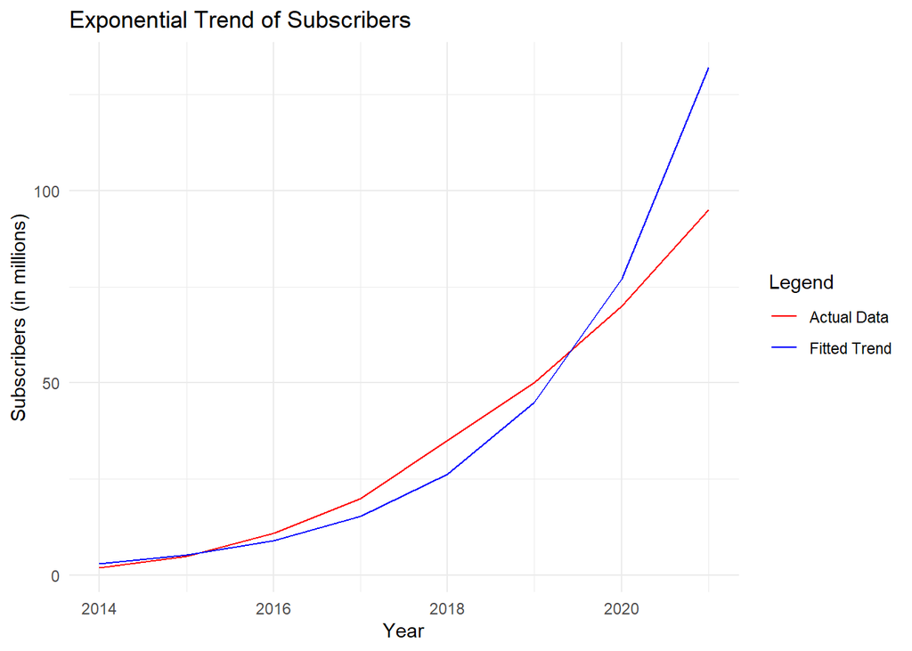

```r
#exponential trend
fitted_log_values<-predict(model)
fitted_values<-exp(fitted_log_values)
#Create a data frame for visualization
data<-data.frame(years=years,subscribers=subscribers,fitted_values=fitted_values)

#Plot
ggplot(data,aes(x=years))+geom_line(aes(y = subscribers, color = "Actual Data"), size = 0.5) +geom_line(aes(y = fitted_values, color = "Fitted Trend"), size = 0.5) +scale_color_manual(name = "Legend", values = c("Actual Data" = "red", "Fitted Trend" = "blue")) +labs(title = "Exponential Trend of Subscribers", x = "Year",y = "Subscribers (in millions)") +theme_minimal()
```

## Coefficients

- **Intercept (**$\alpha$): 1.10731
- **Slope (**$\beta$): 0.53955

These coefficients are used in the log-transformed linear model:

$$\log(Y_t) = \alpha + \beta t$$

Thus,

$$\log(Y_t) = 1.10731 + 0.53955 \cdot t$$

To transform back to the original exponential model:

$$Y_t = e^{1.10731} \cdot e^{0.53955 \cdot t}$$

$$Y_t = 3.026 \cdot e^{0.53955 \cdot t}$$

Where:

$$\beta_0 = e^{1.10731} \approx 3.026$$

$$\beta_1 = 0.53955$$

## Model Fit

- **Multiple R-squared**: 0.9604 (96.04% of the variability in the log of subscribers can be explained by the model).
- **Adjusted R-squared**: 0.9538 (Adjusted for the number of predictors).
- **Residual Standard Error**: 0.2899 (Indicates the average deviation of the actual log-transformed values from the fitted log-transformed values).
- **F-statistic**: 145.5 with a p-value of 1.971e-05 (Indicates that the model is highly significant).

## Visualization Interpretation

### Plot Description

- **Red Line (Actual Data)**: Represents the actual number of subscribers (in millions) from 2014 to 2021.
- **Blue Line (Fitted Trend)**: Represents the exponential trend fitted to the actual data.

## ii. Find the forecast errors.

The forecast error formula is given by:

$$\text{Forecast Error} = \text{Actual Value} - \text{Predicted Value}$$

```r
#(exponential trend)
fitted_values<-exp(predict(model))
#forecast errors
forecast_errors <- subscribers - fitted_values
# Create a data frame with actual subscribers, fitted values, and forecast errors
results_df<-data.frame(Year = years,Actual_Subscribers = subscribers,Fitted_Values = fitted_values, Forecast_Errors = forecast_errors)
print(results_df)
```

```
##   Year Actual_Subscribers Fitted_Values Forecast_Errors
## 1 2014                  2      3.026211      -1.0262112
## 2 2015                  5      5.190675      -0.1906749
## 3 2016                 11      8.903247       2.0967532
## 4 2017                 20     15.271194       4.7288057
## 5 2018                 35     26.193745       8.8062552
## 6 2019                 50     44.928527       5.0714730
## 7 2020                 70     77.063152      -7.0631521
## 8 2021                 95    132.181707     -37.1817074
```

## iii. Use the exponential trend model to predict the number of subscribers for 2024.

```r
#Predict the number of subscribers for 2024
time_2024<-2024-2014
predicted_log_subscribers_2024<-predict(model, newdata = data.frame(time = time_2024))
predicted_subscribers_2024<-exp(predicted_log_subscribers_2024)
cat("Predicted number of subscribers for 2024:",predicted_subscribers_2024, "\n")
```

```
## Predicted number of subscribers for 2024: 667.0296
```

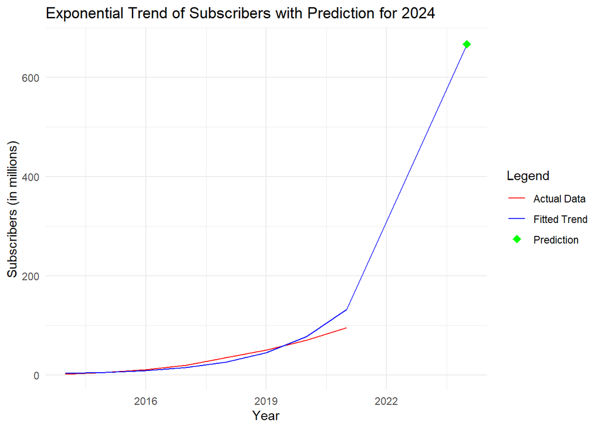

```r
#prediction for 2024 to the data frame
prediction_df<-data.frame(Year=2024,Actual_Subscribers=NA,Fitted_Values=predicted_subscribers_2024,Forecast_Errors=NA)
combined_df<-rbind(results_df, prediction_df)
#Plot
ggplot(combined_df,aes(x=Year))+geom_line(aes(y=Actual_Subscribers,color="Actual Data"),size= 0.5)+geom_line(aes(y = Fitted_Values,color="Fitted Trend"),size=0.5)+geom_point(data=prediction_df,aes(x=Year,y=Fitted_Values,color="Prediction"),size=3,shape=18)+scale_color_manual(name="Legend",values=c("Actual Data"="red","Fitted Trend"="blue","Prediction"="green"))+labs(title="Exponential Trend of Subscribers with Prediction for 2024",x="Year",
y="Subscribers (in millions)")+theme_minimal()
```

The plot shows the actual number of subscribers (in red), the fitted trend (in blue), and the predicted number of subscribers for 2024 (in green).

- **Red Line (Actual Data)**: Represents the actual number of subscribers from 2014 to 2021.
- **Blue Line (Fitted Trend)**: Represents the exponential trend fitted to the actual data.
- **Green Dot (Prediction for 2024)**: Represents the predicted number of subscribers for 2024.

## Observations from the Plot

- **Exponential Growth**: The fitted trend (blue line) clearly shows an exponential growth pattern, where the number of subscribers increases rapidly over time.
- **Prediction for 2024**: The green dot for 2024 shows a substantial increase in the number of subscribers, reaching 667.03 million.
- **Data Fit**: The fitted trend follows the actual data closely until 2020, but it diverges significantly in 2021, indicating potential overestimation in the later years.

The exponential trend model predicts a very high number of subscribers for 2024, which may be overly optimistic given the divergence observed in the later years of the actual data. This indicates that while the exponential model captures the general growth trend, it may not fully account for changes in growth rate or other factors affecting subscriber numbers beyond 2021.